# 5.散佈圖與圓餅圖_Q slides

## 散佈圖與圓餅圖

### Da-Wei Chiang

## 大綱

- 散佈圖
- 圓餅圖

## 散佈圖

```
import matplotlib.pyplot as plt  #引用

plt.scatter(x, y, s, c, alpha, marker)   #繪圖

參數說明：
    x, y : 在(x, y)的位置繪圖
    s : 點的大小
    c : 點的顏色
    alpha : 透明度
    marker : 點的樣式(https://matplotlib.org/stable/api/markers_api.html)
```

## 散佈圖

- 主要繪製連續型資料型態
- 呈現兩個數值型欄位之間的關係

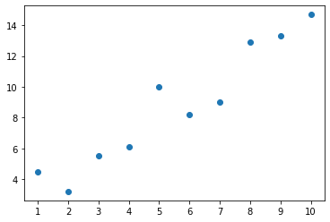

```python
## 範例 - 線性相關

import random
import matplotlib.pyplot as plt
x_coor = list(range(1, 11))
y_coor = [i+round(random.uniform(1, 5), 1) for i in range(1, 11)]

plt.scatter(x_coor, y_coor)
plt.xticks(x_coor)
plt.show()
```

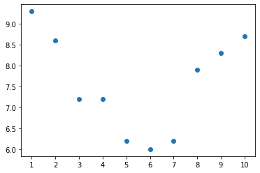

```python
## 範例 - 非線性

import matplotlib.pyplot as plt

x_coor = list(range(1, 11))
y_coor = [9.3, 8.6, 7.2, 7.2, 6.2, 6.0, 6.2, 7.9, 8.3, 8.7]
plt.scatter(x_coor, y_coor)
plt.xticks(x_coor)
plt.show()
```

```
[5 3 1 1 5 1 9 5 4 9]
[7 3 7 4 8 5 3 1 5 5]
```

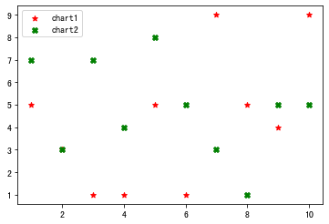

```python
## 範例 - marker
import numpy as np
import random

marker = ['x', 'X', '*', '+']
color = ['c', 'r', 'b', 'g']

data1 = np.random.randint(1, 10, 10)
print(data1)
plt.scatter(range(1, 11), data1, color=random.choice(color), marker=random.choice(marker), label='chart1')
data2 = np.random.randint(1, 10, 10)
plt.scatter(range(1, 11), data2, color=random.choice(color), marker=random.choice(marker), label='chart2')
print(data2)
plt.legend()
plt.show()
```

## 練習資料集

- [Pokemon Detail Data](https://drive.google.com/file/d/1yQQs0ueFive87-UQAK4Mk6RIHFBJvWsQ/view?usp=sharing)

```python
## 查看資料

import pandas as pd

data = pd.read_csv('pokemon.csv')
data

#Total：整體強度
```

|  | Name | Total | HP | Attack | Defence | Sp_attack | Sp_defence | Speed |
| --- | --- | --- | --- | --- | --- | --- | --- | --- |
| 0 | Bulbasaur | 318 | 45 | 49 | 49 | 65 | 65 | 45 |
| 1 | Ivysaur | 405 | 60 | 62 | 63 | 80 | 80 | 60 |
| 2 | Venusaur | 525 | 80 | 82 | 83 | 100 | 100 | 80 |
| 3 | Mega Venusaur | 625 | 80 | 100 | 123 | 122 | 120 | 80 |
| 4 | Charmander | 309 | 39 | 52 | 43 | 60 | 50 | 65 |
| ... | ... | ... | ... | ... | ... | ... | ... | ... |
| 1040 | Glastrier | 580 | 100 | 145 | 130 | 65 | 110 | 30 |
| 1041 | Spectrier | 580 | 100 | 65 | 60 | 145 | 80 | 130 |
| 1042 | Calyrex | 500 | 100 | 80 | 80 | 80 | 80 | 80 |
| 1043 | Mega Calyrex | 680 | 100 | 165 | 150 | 85 | 130 | 50 |
| 1044 | Mega Calyrex X | 680 | 100 | 85 | 80 | 165 | 100 | 150 |

1045 rows × 8 columns

## 練習

- 使用圖表觀察`Attack`及`Defence`是否有關係

## Multi Data Scatter

- 有些情況我們想觀看兩個欄位以上，數值型資料之間的關係

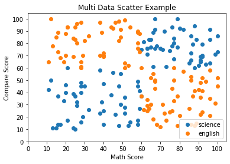

```python
## 範例
import matplotlib.pyplot as plt
import random
math = [random.randint(60, 100) for i in range(50)] + [random.randint(10, 60) for i in range(50)]
science = [random.randint(60, 100) for i in range(50)] + [random.randint(10, 60) for i in range(50)]
english = [random.randint(10, 60) for i in range(50)] + [random.randint(60, 100) for i in range(50)]

plt.scatter(math, science, label="science")
plt.scatter(math, english, label="english")
plt.xticks(list(range(0, 101, 10)))
plt.yticks(list(range(0, 101, 10)))
plt.xlabel("Math Score")
plt.ylabel("Compare Score")
plt.title("Multi Data Scatter Example")
plt.legend()
plt.show()
```

## 練習

- 使用[Pokemon Detail Data](https://drive.google.com/file/d/1yQQs0ueFive87-UQAK4Mk6RIHFBJvWsQ/view?usp=sharing)
- 觀察`Speed`與`Attack`或`Defence`的資料狀況, 並回答下列問題
  - `Speed`跟`Attack`還是`Defence`比較有關係？為什麼？

## 圓餅圖

- 用以呈現類別資料的百分比圖形

## 圓餅圖

```
import matplotlib.pyplot as plt  #引用

plt.pie(data, labels, labeldistance, colors, autopct="%.1f%%", explode, startangle)   #繪圖

# data: 資料
# labels: 資料對應的標籤
# labeldistance: 標籤距離
# color: 資料對應的顏色
# autopct: 資料百分比
# explode: 區塊分離
# startangle: 起始角度
```

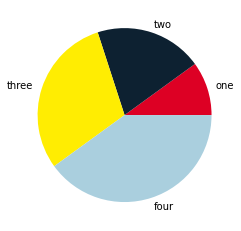

```python
## 範例 - 基礎

import matplotlib.pyplot as plt

plt.pie([10, 20, 30, 40], colors=["#dd0024", "#0d2131", "#ffed02", "#aacfde"], labels=["one", "two", "three", "four"])
plt.show()
```

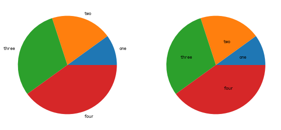

```python
## 範例 - labeldistance

import matplotlib.pyplot as plt

plt.figure(figsize=(10, 5))
plt.subplot(121)
plt.pie([10, 20, 30, 40], labels=["one", "two", "three", "four"])
plt.subplot(122)
plt.pie([10, 20, 30, 40], labels=["one", "two", "three", "four"], labeldistance=0.5)

plt.show()
```

[figure not shown]

```python
## 範例 - autopct
import pandas as pd
import matplotlib.pyplot as plt
dict_data = {
    "Program":["Python", "C#", "Java", "PHP"],
    "Percent":[48, 25, 20, 7]
}

df = pd.DataFrame(dict_data)
plt.pie(df["Percent"],labels=df["Program"].values, autopct="%d%%")
plt.title("Program Population")
plt.show()
```

```
[3 8 1 1 6]
```

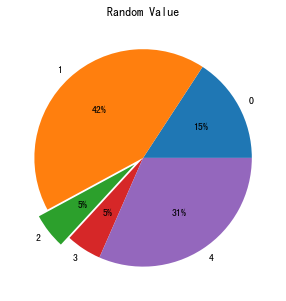

```python
## 範例 - exp
import pandas as pd
import matplotlib.pyplot as plt
import numpy as np

plt.figure(figsize=(5, 5))
data = np.random.randint(1, 10, 5)
print(data)
exp = [0, 0, 0.1, 0, 0]
plt.pie(data,labels=range(5), autopct="%d%%", explode=exp)
plt.title("Random Value")
plt.show()
```

```
[3 6 5 7 8]
```

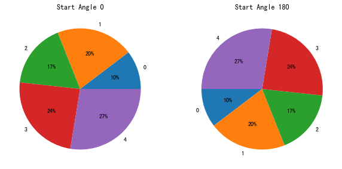

```python
## 範例 - startangle
import pandas as pd
import matplotlib.pyplot as plt
import numpy as np

plt.figure(figsize=(10, 10))
data = np.random.randint(1, 10, 5)
print(data)
chart1 = plt.subplot(121)
chart1.pie(data,labels=range(5), autopct="%d%%")
chart1.set_title("Start Angle 0")
chart2 = plt.subplot(122)
chart2.pie(data,labels=range(5), autopct="%d%%", startangle=180)
chart2.set_title("Start Angle 180")
plt.show()
```

## 練習

- 請自行練習基本圓餅圖設定

## 進階圓餅圖設定

- 當繪製圓餅圖使用`plt.pie()`方法時, 會有三個回傳值.如下所示

```
patches, texts, autotexts = plt.pie(...)

## patches: 圓餅圖邊界設定
## texts: 圓餅圖標籤設定
## autotexts: 圓餅圖百分比設定
```

```python
## 查看plt.pie方法
import matplotlib.pyplot as plt

print(help(plt.pie))
```

```
Help on function pie in module matplotlib.pyplot:

pie(x, explode=None, labels=None, colors=None, autopct=None, pctdistance=0.6, shadow=False, labeldistance=1.1, startangle=0, radius=1, counterclock=True, wedgeprops=None, textprops=None, center=(0, 0), frame=False, rotatelabels=False, *, normalize=None, data=None)
    Plot a pie chart.

    Make a pie chart of array *x*.  The fractional area of each wedge is
    given by ``x/sum(x)``.  If ``sum(x) < 1``, then the values of *x* give
    the fractional area directly and the array will not be normalized. The
    resulting pie will have an empty wedge of size ``1 - sum(x)``.

    The wedges are plotted counterclockwise, by default starting from the
    x-axis.

    Parameters
    ----------
    x : 1D array-like
        The wedge sizes.

    explode : array-like, default: None
        If not *None*, is a ``len(x)`` array which specifies the fraction
        of the radius with which to offset each wedge.

    labels : list, default: None
        A sequence of strings providing the labels for each wedge

    colors : array-like, default: None
        A sequence of colors through which the pie chart will cycle.  If
        *None*, will use the colors in the currently active cycle.

    autopct : None or str or callable, default: None
        If not *None*, is a string or function used to label the wedges
        with their numeric value.  The label will be placed inside the
        wedge.  If it is a format string, the label will be ``fmt % pct``.
        If it is a function, it will be called.

    pctdistance : float, default: 0.6
        The ratio between the center of each pie slice and the start of
        the text generated by *autopct*.  Ignored if *autopct* is *None*.

    shadow : bool, default: False
```

[output cut: 64 more lines]

```
    square, or the Axes aspect is equal.
    This method sets the aspect ratio of the axis to "equal".
    The Axes aspect ratio can be controlled with `.Axes.set_aspect`.

    .. note::
        In addition to the above described arguments, this function can take
        a *data* keyword argument. If such a *data* argument is given,
        the following arguments can also be string ``s``, which is
        interpreted as ``data[s]`` (unless this raises an exception):
        *x*, *explode*, *labels*, *colors*.

        Objects passed as **data** must support item access (``data[s]``) and
        membership test (``s in data``).

None
```

## 標籤與百分比字體樣式設定

```
set_color(color) #顏色設定
set_size(number) #字體設定
```

```
[9 8 6 1 9]
[Text(0.720346786112299, 0.8313245501834299, 'one'), Text(-0.8646584543764556, 0.6799748210598089, 'two'), Text(-0.8646583270487659, -0.6799749829701308, 'three'), Text(-0.2593346865131817, -1.0689927597374596, 'four'), Text(0.7203469417807291, -0.8313244152959488, 'five')]
```

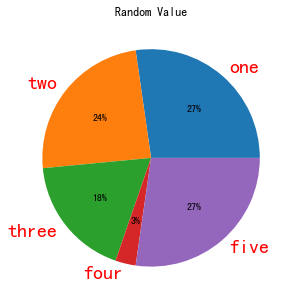

```python
## 範例 - 標籤設定

import pandas as pd
import matplotlib.pyplot as plt
import numpy as np

plt.figure(figsize=(5, 5))
data = np.random.randint(1, 10, 5)
print(data)
patches, texts, autotexts = plt.pie(data,labels=['one', 'two', 'three', 'four', 'five'], autopct="%d%%")
print(texts)
for i in texts:
    i.set_color('red')
    i.set_size(20)
plt.title("Random Value")
plt.show()
```

```
[2 4 1 5 4]
[Text(0.5543277195067721, 0.22961005941905385, '12%'), Text(3.6739403974420595e-17, 0.6, '25%'), Text(-0.4988817673815272, 0.3333421398117613, '6%'), Text(-0.49888176738152723, -0.33334213981176114, '31%'), Text(0.42426406871192845, -0.4242640687119286, '25%')]
```

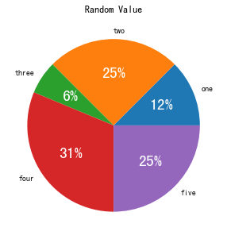

```python
## 範例 - 百分比設定

import pandas as pd
import matplotlib.pyplot as plt
import numpy as np

plt.figure(figsize=(5, 5))
data = np.random.randint(1, 10, 5)
print(data)
patches, texts, autotexts = plt.pie(data,labels=['one', 'two', 'three', 'four', 'five'], autopct="%d%%")
print(autotexts)
for i in autotexts:
    i.set_color('w')
    i.set_size(20)
plt.title("Random Value")
plt.show()
```

## 邊界樣式設定

```
set_edgecolor(color) #設定邊界顏色
set_linewidth(number) #設定邊界粗細
```

[output not shown]

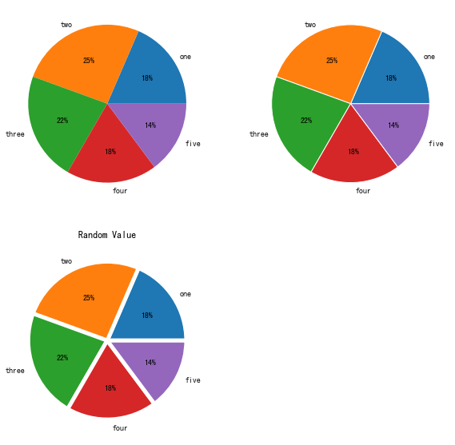

```python
## 範例 - 邊界設定

import pandas as pd
import matplotlib.pyplot as plt
import numpy as np

plt.figure(figsize=(10, 10))
data = np.random.randint(1, 10, 5)
print(data)
chart1 = plt.subplot(221)
chart1.pie(data,labels=['one', 'two', 'three', 'four', 'five'], autopct="%d%%")
chart2 = plt.subplot(222)
patches, texts, autotexts = plt.pie(data,labels=['one', 'two', 'three', 'four', 'five'], autopct="%d%%")
print(patches)
for i in patches:
    i.set_edgecolor('w')
chart3 = plt.subplot(223)
patches, texts, autotexts = plt.pie(data,labels=['one', 'two', 'three', 'four', 'five'], autopct="%d%%")
for i in patches:
    i.set_edgecolor('w')
    i.set_linewidth(5)

plt.title("Random Value")
plt.show()
```

## 練習

- 請自行練習文字、百分比、邊界設定

## 環狀圓餅圖

- 環狀圓餅圖的概念即是在同一張畫布上畫兩次圓餅圖
  - 為了怕外部的百分比壓到內部的圓, 需設定`pctdistance`
  - 內部的圓需設定半徑`radius`否則會壓到外部的圓

```
[3 4 4 7 5]
```

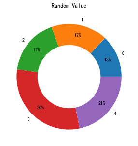

```python
## 範例 - 環狀圓餅圖
import pandas as pd
import matplotlib.pyplot as plt
import numpy as np

plt.figure(figsize=(5, 5))
data = np.random.randint(1, 10, 5)
print(data)
plt.pie(data,labels=range(5), autopct="%d%%", pctdistance=0.8)  #第一個繪製的圓餅圖為外圓, 需設pctdistance
plt.pie([0, 1], radius=0.6, colors='w')  #第二個繪製的圓餅圖需設radius
plt.title("Random Value")
plt.show()
```

## 練習

- 已知某大學資工系、資管系、資通系學生人數為`450, 420, 400`且這三個科系的男女人數為`1200, 70`請繪製圓餅圖如下圖所示.

[figure not shown]

## 練習資料集

- [imdb top 1000](https://drive.google.com/file/d/1J6lJiQ3PjMMh8PESBNM0klpM3z1UNLB0/view?usp=sharing)

```python
## 查看資料

import pandas
data = pandas.read_csv('imdb_top_1000.csv')
data
```

|  | Poster_Link | Series_Title | Released_Year | Certificate | Runtime | Genre | IMDB_Rating | Overview | Meta_score | Director | Star1 | Star2 | Star3 | Star4 | No_of_Votes | Gross |
| --- | --- | --- | --- | --- | --- | --- | --- | --- | --- | --- | --- | --- | --- | --- | --- | --- |
| 0 | https://m.media-amazon.com/images/M/MV5BMDFkYT... | The Shawshank Redemption | 1994 | A | 142 min | Drama | 9.3 | Two imprisoned men bond over a number of years... | 80.0 | Frank Darabont | Tim Robbins | Morgan Freeman | Bob Gunton | William Sadler | 2343110 | 28,341,469 |
| 1 | https://m.media-amazon.com/images/M/MV5BM2MyNj... | The Godfather | 1972 | A | 175 min | Crime, Drama | 9.2 | An organized crime dynasty's aging patriarch t... | 100.0 | Francis Ford Coppola | Marlon Brando | Al Pacino | James Caan | Diane Keaton | 1620367 | 134,966,411 |
| 2 | https://m.media-amazon.com/images/M/MV5BMTMxNT... | The Dark Knight | 2008 | UA | 152 min | Action, Crime, Drama | 9.0 | When the menace known as the Joker wreaks havo... | 84.0 | Christopher Nolan | Christian Bale | Heath Ledger | Aaron Eckhart | Michael Caine | 2303232 | 534,858,444 |
| 3 | https://m.media-amazon.com/images/M/MV5BMWMwMG... | The Godfather: Part II | 1974 | A | 202 min | Crime, Drama | 9.0 | The early life and career of Vito Corleone in ... | 90.0 | Francis Ford Coppola | Al Pacino | Robert De Niro | Robert Duvall | Diane Keaton | 1129952 | 57,300,000 |
| 4 | https://m.media-amazon.com/images/M/MV5BMWU4N2... | 12 Angry Men | 1957 | U | 96 min | Crime, Drama | 9.0 | A jury holdout attempts to prevent a miscarria... | 96.0 | Sidney Lumet | Henry Fonda | Lee J. Cobb | Martin Balsam | John Fiedler | 689845 | 4,360,000 |
| ... | ... | ... | ... | ... | ... | ... | ... | ... | ... | ... | ... | ... | ... | ... | ... | ... |
| 995 | https://m.media-amazon.com/images/M/MV5BNGEwMT... | Breakfast at Tiffany's | 1961 | A | 115 min | Comedy, Drama, Romance | 7.6 | A young New York socialite becomes interested ... | 76.0 | Blake Edwards | Audrey Hepburn | George Peppard | Patricia Neal | Buddy Ebsen | 166544 | NaN |
| 996 | https://m.media-amazon.com/images/M/MV5BODk3Yj... | Giant | 1956 | G | 201 min | Drama, Western | 7.6 | Sprawling epic covering the life of a Texas ca... | 84.0 | George Stevens | Elizabeth Taylor | Rock Hudson | James Dean | Carroll Baker | 34075 | NaN |
| 997 | https://m.media-amazon.com/images/M/MV5BM2U3Yz... | From Here to Eternity | 1953 | Passed | 118 min | Drama, Romance, War | 7.6 | In Hawaii in 1941, a private is cruelly punish... | 85.0 | Fred Zinnemann | Burt Lancaster | Montgomery Clift | Deborah Kerr | Donna Reed | 43374 | 30,500,000 |
| 998 | https://m.media-amazon.com/images/M/MV5BZTBmMj... | Lifeboat | 1944 | NaN | 97 min | Drama, War | 7.6 | Several survivors of a torpedoed merchant ship... | 78.0 | Alfred Hitchcock | Tallulah Bankhead | John Hodiak | Walter Slezak | William Bendix | 26471 | NaN |
| 999 | https://m.media-amazon.com/images/M/MV5BMTY5OD... | The 39 Steps | 1935 | NaN | 86 min | Crime, Mystery, Thriller | 7.6 | A man in London tries to help a counter-espion... | 93.0 | Alfred Hitchcock | Robert Donat | Madeleine Carroll | Lucie Mannheim | Godfrey Tearle | 51853 | NaN |

1000 rows × 16 columns

## 練習

- 繪製年份次數圓餅圖
  - 只繪製年份出現次數大於25的資料
- 回答下列問題
  - 在該資料中次數大於25的年份站圓餅圖多少百分比?為哪一年？
  - 該份資料中有個年份的錯誤值為何？是第幾筆資料？